# Can We Predict Who Will Get Approved for a Credit Card?

Vidit Makwana, Harleen Kaur, and Sophie Jorgensen

# Introduction

Applying for credit cards can be a tricky decision for individuals. Depending on the company's policy and application review process, even [one application for a credit card](https://www.nerdwallet.com/article/finance/multiple-credit-card-applications-hurt-credit-score#:~:text=Applying%20for%20credit%20cards%20can,someone%20who%20applies%20less%20often) can knock a few points off of one's credit score. Thus, we wanted to test our different prediction models to see if any or multiple of them would be beneficial for users to test their own likelihood of getting approved. If they use a tool of this sort and it seems like they would not get approved, they could try to "improve" components of their application before applying. This could help prevent individuals from losing points on their credit score due to numerous credit card applications.

Before diving into our experimental process, we will define the features of our referenced data set.

- *Gender:* The gender of the applicant. Coded as 0=Female and 1=Male.
- *Age:* The age of the applicant. Coded in years.
- *Debt:* The outstanding debt of the applicant. This feature has been scaled.
- *Married:* The marital status of the applicant. Coded as 0=Single, Divorced, etc. and 1=Married.
- *BankCustomer:* Whether the applicant has a bank account. Coded as 0=Does not have a bank account and 1=Has a bank account.
- *Industry:* The job sector of the applicant's current or most recent job. Coded categorically, with a variety of industries including Industrials, Energy, and Consumer Staples.
- *Ethnicity:* The ethnicity of the applicant. Coded categorically, with a variety of ethnicities such as White, Black, and Latino.
- *YearsEmployed:* The number of years the applicant has been employed cumulatively over their life. Coded in years.
- *PriorDefault:* Whether or not the applicant has ever defaulted their credit card. A default is when a card owner fails to pay the minimum amount due on the card for several months. Coded as 0=Has not had a prior defaults and 1=Has had a prior default.
- *Employed:* Whether or not the applicant is currently employed. Coded as 0=Is not currently employed and 1=Is currently employed.
- *CreditScore:* The credit score of the applicant. This is a numeric score assigned to a card borrower based on their ability to make consistent payments, their financial history, and their current financial situation.
- *DriversLicense:* Whether or not the applicant has a driver's licenese. Coded as 0=Does not have a driver's license and 1=Has a driver's license.
- *Citizen:* The method of obtaining citizenship or citizenship status of the applicant. Coded categorically, as ByBirth, ByOtherMeans, or Temporary.
- *ZipCode:* The zip code of the applicant's residence. Coded numerically as the exact zip code entails.
- *Income:* The annual income of the applicant. This feature is scaled.
- *Approved:* Whether or not the applicant was approved for this credit card they applied to. Coded as 0=Not approved and 1=Approved.

```python
import pandas as pd
import numpy as np
import seaborn as sns
from sklearn.svm import SVC
from matplotlib import pyplot as plt

# Load the dataset into a pandas dataframe
df = pd.read_csv("sample_data/clean_dataset.csv")
df.head(10)
```

|  | Gender | Age | Debt | Married | BankCustomer | Industry | Ethnicity | YearsEmployed | PriorDefault | Employed | CreditScore | DriversLicense | Citizen | ZipCode | Income | Approved |
| --- | --- | --- | --- | --- | --- | --- | --- | --- | --- | --- | --- | --- | --- | --- | --- | --- |
| 0 | 1 | 30.83 | 0.000 | 1 | 1 | Industrials | White | 1.250 | 1 | 1 | 1 | 0 | ByBirth | 202 | 0 | 1 |
| 1 | 0 | 58.67 | 4.460 | 1 | 1 | Materials | Black | 3.040 | 1 | 1 | 6 | 0 | ByBirth | 43 | 560 | 1 |
| 2 | 0 | 24.50 | 0.500 | 1 | 1 | Materials | Black | 1.500 | 1 | 0 | 0 | 0 | ByBirth | 280 | 824 | 1 |
| 3 | 1 | 27.83 | 1.540 | 1 | 1 | Industrials | White | 3.750 | 1 | 1 | 5 | 1 | ByBirth | 100 | 3 | 1 |
| 4 | 1 | 20.17 | 5.625 | 1 | 1 | Industrials | White | 1.710 | 1 | 0 | 0 | 0 | ByOtherMeans | 120 | 0 | 1 |
| 5 | 1 | 32.08 | 4.000 | 1 | 1 | CommunicationServices | White | 2.500 | 1 | 0 | 0 | 1 | ByBirth | 360 | 0 | 1 |
| 6 | 1 | 33.17 | 1.040 | 1 | 1 | Transport | Black | 6.500 | 1 | 0 | 0 | 1 | ByBirth | 164 | 31285 | 1 |
| 7 | 0 | 22.92 | 11.585 | 1 | 1 | InformationTechnology | White | 0.040 | 1 | 0 | 0 | 0 | ByBirth | 80 | 1349 | 1 |
| 8 | 1 | 54.42 | 0.500 | 0 | 0 | Financials | Black | 3.960 | 1 | 0 | 0 | 0 | ByBirth | 180 | 314 | 1 |
| 9 | 1 | 42.50 | 4.915 | 0 | 0 | Industrials | White | 3.165 | 1 | 0 | 0 | 1 | ByBirth | 52 | 1442 | 1 |

# Data Cleanup

To start off, we want to check and see if there are any missing values in the data frame.

```python
df.isnull().sum().sum()
```

```
0
```

Since there are no missing values, we do not need to pad any values in the data frame or delete rows/columns. So, we can proceed for further cleanup. We want to see if we need to change any encodings of values to make more sense for our analysis. We notice that several columns are encoded as boolean 0/1 values. For columns like "BankCustomer" and "Employed," we know 1 equates to yes and 0 equates to no. However, for Gender, this is confusing. A quick reference to the original source reveals that 0=Female and 1=Male. Though a string saying F or M may be easier to read in the dataframe, we will leave it as a 0/1 encoding for easier processing.

When referencing the data set description on Kaggle, we see that Income, Debt, and Credit Score have been scaled. Since we do not have access to the original, un-scaled data set, we cannot make meaningful changes to these values. Debt and income scales follow the suit the reader would think: a lower numeric value for debt means a lower amount of monetary debt, and a higher numeric value for income means a higher amount of monetary income. However, credit card score scale does not confer a clear encoding. There are unanswered questions as to whether a lower or higher numeric value in this column relates to an excellent or poor credit score, and we do not have access to the original, confidential data set to provide an answer. To try and figure this out, we analyze the data frame further.

```python
copy_df = df
copy_df = copy_df[copy_df.Approved != 0]
df.mode()
```

|  | Gender | Age | Debt | Married | BankCustomer | Industry | Ethnicity | YearsEmployed | PriorDefault | Employed | CreditScore | DriversLicense | Citizen | ZipCode | Income | Approved |
| --- | --- | --- | --- | --- | --- | --- | --- | --- | --- | --- | --- | --- | --- | --- | --- | --- |
| 0 | 1 | 28.46 | 1.5 | 1 | 1 | Energy | White | 0.0 | 1 | 0 | 0 | 0 | ByBirth | 0 | 0 | 0 |

```python
df = df.drop(columns=["CreditScore"])
print(df.head())
```

```
   Gender    Age   Debt  Married  BankCustomer     Industry Ethnicity  \
0       1  30.83  0.000        1             1  Industrials     White
1       0  58.67  4.460        1             1    Materials     Black
2       0  24.50  0.500        1             1    Materials     Black
3       1  27.83  1.540        1             1  Industrials     White
4       1  20.17  5.625        1             1  Industrials     White

   YearsEmployed  PriorDefault  Employed  DriversLicense       Citizen  \
0           1.25             1         1               0       ByBirth
1           3.04             1         1               0       ByBirth
2           1.50             1         0               0       ByBirth
3           3.75             1         1               1       ByBirth
4           1.71             1         0               0  ByOtherMeans

   ZipCode  Income  Approved
0      202       0         1
1       43     560         1
2      280     824         1
3      100       3         1
4      120       0         1
```

We also want to make sure all of the other columns in our analysis are relevant in helping predict credit card approvals. Next, we take a look at zip codes. There are over 41,000 zip codes in the United States, and many zip codes that directly border each other may not have similar characteristics. For example, in Washington, D.C., there are drastic differences in the percentage of people living below the poverty line across zipcodes ([see this graph for reference](https://www.dchealthmatters.org/indicators/index/view?indicatorId=347&localeTypeId=3&periodId=9907)). Additionally, numeric values of zip codes are generally near those neighboring them, and as evident from the graph, even neighboring zip codes may not have much in common. Thus, it is unrealistic to use the numeric value of zip codes all across the United States in a meaningful way in terms of credit card approval predictions. So, we drop zip codes from the data frame.

```python
df = df.drop(columns=["ZipCode"])
print(df.head())
```

```
   Gender    Age   Debt  Married  BankCustomer     Industry Ethnicity  \
0       1  30.83  0.000        1             1  Industrials     White
1       0  58.67  4.460        1             1    Materials     Black
2       0  24.50  0.500        1             1    Materials     Black
3       1  27.83  1.540        1             1  Industrials     White
4       1  20.17  5.625        1             1  Industrials     White

   YearsEmployed  PriorDefault  Employed  DriversLicense       Citizen  \
0           1.25             1         1               0       ByBirth
1           3.04             1         1               0       ByBirth
2           1.50             1         0               0       ByBirth
3           3.75             1         1               1       ByBirth
4           1.71             1         0               0  ByOtherMeans

   Income  Approved
0       0         1
1     560         1
2     824         1
3       3         1
4       0         1
```

The other columns seem relevant (as they pertain to financials, social status, occupation, and demographics), so we leave them in the data frame.

We now perform some feature engineering to produce figures we believe may be helpful in predicting credit card approvals. We think the proportion of years worked relative to one's age may reveal how economically successful one is, and hence could relate to financial matters like credit cards. Thus, we calculate this and add it to the data frame.

```python
df['PropYearsWorked'] = df['YearsEmployed'] / df['Age']
print(df.head())
```

```
   Gender    Age   Debt  Married  BankCustomer     Industry Ethnicity  \
0       1  30.83  0.000        1             1  Industrials     White
1       0  58.67  4.460        1             1    Materials     Black
2       0  24.50  0.500        1             1    Materials     Black
3       1  27.83  1.540        1             1  Industrials     White
4       1  20.17  5.625        1             1  Industrials     White

   YearsEmployed  PriorDefault  Employed  DriversLicense       Citizen  \
0           1.25             1         1               0       ByBirth
1           3.04             1         1               0       ByBirth
2           1.50             1         0               0       ByBirth
3           3.75             1         1               1       ByBirth
4           1.71             1         0               0  ByOtherMeans

   Income  Approved  PropYearsWorked
0       0         1         0.040545
1     560         1         0.051815
2     824         1         0.061224
3       3         1         0.134747
4       0         1         0.084779
```

# Preprocessing

In order to visualize our data in certain ways and train our models, we need to convert categorical data such as the Citizen and Industry columns to numeric values.

```python
from sklearn import preprocessing
le = preprocessing.LabelEncoder()

# Encode Citizen to a numeric value
df['Citizen'] = le.fit_transform(df['Citizen'])

# Encode Ethnicity to a numeric value
df['Ethnicity'] = le.fit_transform(df['Ethnicity'])

# Encode Industry to a numeric value
df['Industry'] = le.fit_transform(df['Industry'])

df.head()
```

|  | Gender | Age | Debt | Married | BankCustomer | Industry | Ethnicity | YearsEmployed | PriorDefault | Employed | DriversLicense | Citizen | Income | Approved | PropYearsWorked |
| --- | --- | --- | --- | --- | --- | --- | --- | --- | --- | --- | --- | --- | --- | --- | --- |
| 0 | 1 | 30.83 | 0.000 | 1 | 1 | 7 | 4 | 1.25 | 1 | 1 | 0 | 0 | 0 | 1 | 0.040545 |
| 1 | 0 | 58.67 | 4.460 | 1 | 1 | 9 | 1 | 3.04 | 1 | 1 | 0 | 0 | 560 | 1 | 0.051815 |
| 2 | 0 | 24.50 | 0.500 | 1 | 1 | 9 | 1 | 1.50 | 1 | 0 | 0 | 0 | 824 | 1 | 0.061224 |
| 3 | 1 | 27.83 | 1.540 | 1 | 1 | 7 | 4 | 3.75 | 1 | 1 | 1 | 0 | 3 | 1 | 0.134747 |
| 4 | 1 | 20.17 | 5.625 | 1 | 1 | 7 | 4 | 1.71 | 1 | 0 | 0 | 1 | 0 | 1 | 0.084779 |

# Data Visualization

Now that we have cleaned and tidied the data, let's explore patterns, trends and anything that may confirm or deny our initial assumptions.

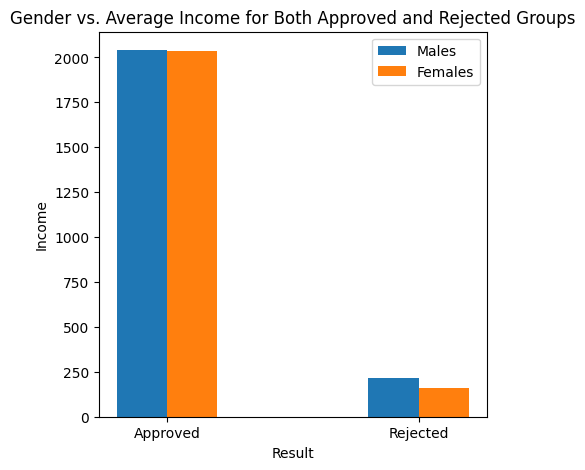

```python
# Number of pairs to include (Approved and Rejected)
N = 2

# Male and Female values
avg_income_male_app = 0 # approved
avg_income_female_app = 0 # approved
avg_income_male_noapp = 0 # not approved
avg_income_female_noapp = 0 # not approved
income_males_app = []
income_females_app = []
income_males_noapp = []
income_females_noapp = []

# Find all of the appropriate incomes
for index, row in df.iterrows():
  if row['Gender'] == 1:
    if row['Approved'] == 1:
      income_males_app.append(row['Income'])
    else:
      income_males_noapp.append(row['Income'])
  else:
    if row['Approved'] == 1:
      income_females_app.append(row['Income'])
    else:
      income_females_noapp.append(row['Income'])

# Average the incomes for each group
avg_income_male_app = np.average(income_males_app)
avg_income_female_app = np.average(income_females_app)
avg_income_male_noapp = np.average(income_males_noapp)
avg_income_female_noapp = np.average(income_females_noapp)

# Store the data to be put in the graph
males = (avg_income_male_app, avg_income_male_noapp)
females = (avg_income_female_app, avg_income_female_noapp)

# Position of bars on x-axis
pos = np.arange(N)

# Figure size
plt.figure(figsize=(5,5))

# Width of a bar
width = 0.2

# Plotting
plt.bar(pos, males , width, label='Males')
plt.bar(pos + width, females, width, label='Females')

plt.xlabel('Result')
plt.ylabel('Income')
plt.title('Gender vs. Average Income for Both Approved and Rejected Groups')
plt.xticks(pos + width / 2, ('Approved', 'Rejected'))

plt.legend(loc='best')
plt.show()
```

Let's first explore the income disparity between both those who were approved and rejected. Let's also explore if this differs between males and females. We assumed that anyone with a higher average income were less likely to be rejected. Looking at this side-by-side bar graph, we observe that the assumption is confirmed. There is drastic difference in average income between those who were approved versus those who were rejected. Additionally, the average income for both males and females are similar but that of females is lower. We can read more into this gap [here](https://www.pewresearch.org/short-reads/2023/03/01/gender-pay-gap-facts/).

Another factor that influences if one gets approved for a credit card or not is employment. When banks consider rejecting or approving a candidate they look at whether the candidate has a steady job to pay off their credit card. Through the data, we can explore whether the years that one has held a job affects getting a credit card or not.

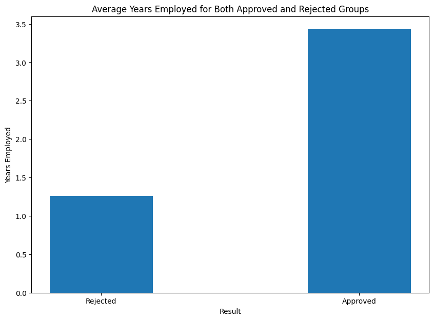

```python
#Making groups rejected & approved
approved = [0,1]

#Collecting the number of years employed for both groups
years = []
for i in approved:
  l = df.loc[df['Approved'] == i]
  years.append(l['YearsEmployed'])

#Averaging the years employed for both groups
Y = (np.average(years[0]), np.average(years[1]))

#Setting figure size
fig = plt.figure(figsize =(10, 7))

# Width of a bar
width = 0.4

#Plotting and setting labels
plt.bar(approved, Y, width=width)
plt.xlabel('Result')
plt.ylabel('Years Employed')
plt.title('Average Years Employed for Both Approved and Rejected Groups')
plt.xticks(approved, ('Rejected', 'Approved'))

plt.show()
```

Looking at the bar graph above we can see that our assumption was correct. The average years employed for people who have been rejected is a lot lower than the for the people who got approves. This tells us that candidates who have not worked for a long period of time are likely to get rejected for a credit card application. Thus, people looking to get approved should consider having a steady job for a couple of years to get a credit card approval.

We can also see what occupations are more likely to get approved for a credit card application and which are not.

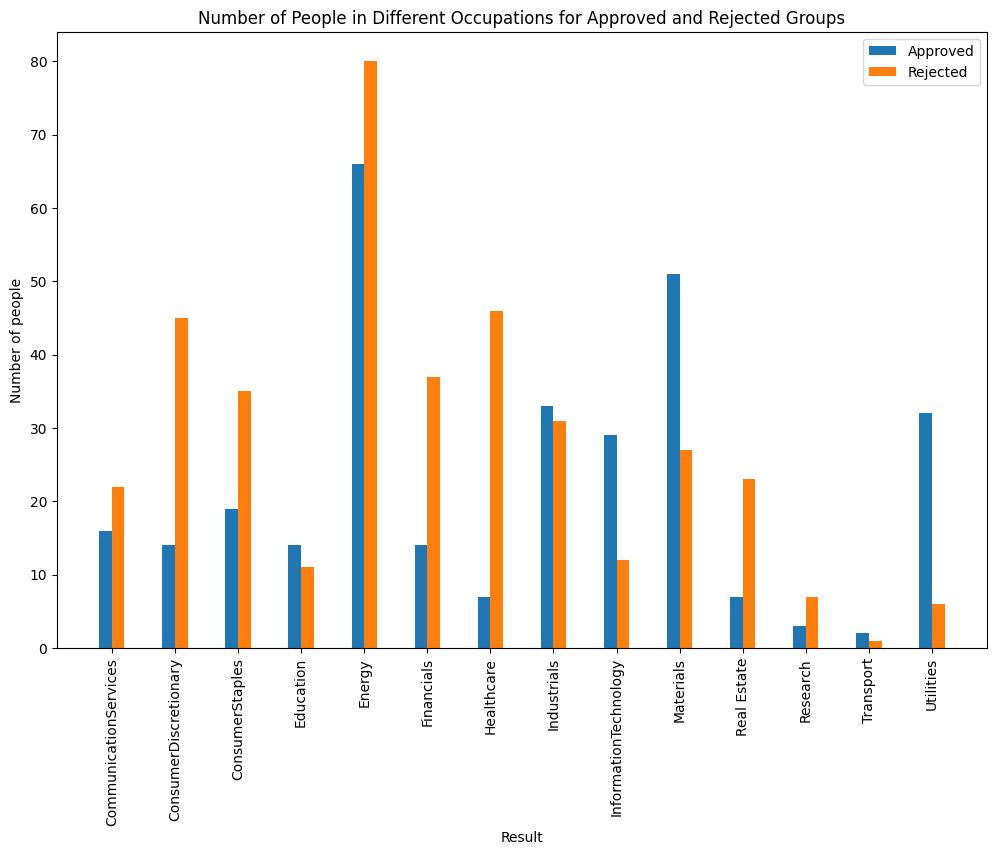

```python
#Since indsutry is a coded value need to get the classification for label
le_industry_mapping = dict(zip(le.classes_, le.transform(le.classes_)))
labels = list(le_industry_mapping.keys())

#Gathering data points for 13 different industries
Y = []
X = np.arange(14)

#Store data to put in graph
for i in X:
  l = df.loc[df['Industry'] == i]
  Y.append(l['Approved'])

#Accumulate data to generate graph
industries = []
non_industries = []
for y in Y:
  i = []
  for l in y:
    if l == 0:
      i.append(1)
  non_industries.append(np.sum(i))
  industries.append(np.sum(y))

# Position of bars on x-axis
pos = np.arange(len(labels))

# Figure size
plt.figure(figsize=(12, 8))

# Width of a bar
width = 0.2

# Plotting
plt.bar(pos, industries , width, label='Approved')
plt.bar(pos + width, non_industries, width, label='Rejected')
plt.xlabel('Result')
plt.ylabel('Number of people')
plt.title('Number of People in Different Occupations for Approved and Rejected Groups')
plt.xticks(pos + width / 2, labels, rotation='vertical')

plt.legend(loc='best')
plt.show()
```

# Decision Tree

We first try to create and test a decision tree classifier. We use a 70/30 split between training and testing data because this is common practice in machine learning and has empirically led to the best training of models ([see this article for reference](https://scholarworks.utep.edu/cs_techrep/1209/)).

```python
from sklearn.model_selection import train_test_split

# Conduct a 70/30 split across the data, placing rows into training_data
# and testing_data respectively
train_data, test_data = train_test_split(df, test_size=0.3, random_state=42)

print(f"Number of training examples: {train_data.shape[0]}")
print(f"Number of testing examples: {test_data.shape[0]}")

test_data.head()
```

```
Number of training examples: 483
Number of testing examples: 207
```

|  | Gender | Age | Debt | Married | BankCustomer | Industry | Ethnicity | YearsEmployed | PriorDefault | Employed | DriversLicense | Citizen | Income | Approved | PropYearsWorked |
| --- | --- | --- | --- | --- | --- | --- | --- | --- | --- | --- | --- | --- | --- | --- | --- |
| 286 | 0 | 28.46 | 1.5 | 1 | 1 | 6 | 2 | 0.0 | 0 | 1 | 1 | 0 | 105 | 0 | 0.000000 |
| 511 | 0 | 46.00 | 4.0 | 1 | 1 | 11 | 3 | 0.0 | 1 | 0 | 0 | 0 | 960 | 1 | 0.000000 |
| 257 | 1 | 20.00 | 0.0 | 1 | 1 | 10 | 4 | 0.5 | 0 | 0 | 0 | 0 | 0 | 0 | 0.025000 |
| 336 | 1 | 47.33 | 6.5 | 1 | 1 | 4 | 4 | 1.0 | 0 | 0 | 1 | 0 | 228 | 0 | 0.021128 |
| 318 | 1 | 19.17 | 0.0 | 0 | 0 | 0 | 0 | 0.0 | 0 | 0 | 1 | 1 | 1 | 1 | 0.000000 |

Decision trees are a supervised learning technique, and thus we need to separate the testing and training data into X and Y components. We are trying to predict credit card approval from the input features, and thus Approved status will be our Y value and the rest of the data frame minus the Approved column will be the X values.

```python
# Separate training data into X and Y
train_data_y = train_data['Approved']
train_data_x = train_data.drop('Approved', axis=1)

# Separate testing data into X and Y
test_data_y = test_data['Approved']
test_data_x = test_data.drop('Approved', axis=1)

# Data frame with no Approved column
test_data_x.head()
```

|  | Gender | Age | Debt | Married | BankCustomer | Industry | Ethnicity | YearsEmployed | PriorDefault | Employed | DriversLicense | Citizen | Income | PropYearsWorked |
| --- | --- | --- | --- | --- | --- | --- | --- | --- | --- | --- | --- | --- | --- | --- |
| 286 | 0 | 28.46 | 1.5 | 1 | 1 | 6 | 2 | 0.0 | 0 | 1 | 1 | 0 | 105 | 0.000000 |
| 511 | 0 | 46.00 | 4.0 | 1 | 1 | 11 | 3 | 0.0 | 1 | 0 | 0 | 0 | 960 | 0.000000 |
| 257 | 1 | 20.00 | 0.0 | 1 | 1 | 10 | 4 | 0.5 | 0 | 0 | 0 | 0 | 0 | 0.025000 |
| 336 | 1 | 47.33 | 6.5 | 1 | 1 | 4 | 4 | 1.0 | 0 | 0 | 1 | 0 | 228 | 0.021128 |
| 318 | 1 | 19.17 | 0.0 | 0 | 0 | 0 | 0 | 0.0 | 0 | 0 | 1 | 1 | 1 | 0.000000 |

To further confirm our training and testing data got split correctly, we print the shapes of them.

```python
# Print the shapes of training and testing data
train_data_x.shape, train_data_y.shape, test_data_x.shape, test_data_y.shape
```

```
((483, 14), (483,), (207, 14), (207,))
```

The splits look as expected: the training data has 483 values, across 14 features for the X and one feature for the Y, and the test data has 207 values, across 14 features for the X and one feature for the Y.

```python
from sklearn import tree
from sklearn import metrics

# initialize the classifier
dt = tree.DecisionTreeClassifier()

# train the classifier
dt.fit(train_data_x, train_data_y)

# predict the Y from the test data
y_pred = dt.predict(test_data_x)

# model accuracy
print("Accuracy:", round(metrics.accuracy_score(test_data_y, y_pred) * 100, 2))

# model f1 score
print("F1 Score:", round(metrics.f1_score(test_data_y, y_pred)  * 100, 2))
```

```
Accuracy: 77.78
F1 Score: 76.04
```

Our decision tree classifier achieves an accuracy of 77.78% and an F1 score of 76.04%.

```
[Text(0.44869402985074625, 0.9545454545454546, 'x[8] <= 0.5\ngini = 0.491\nsamples = 483\nvalue = [273, 210]'),
```

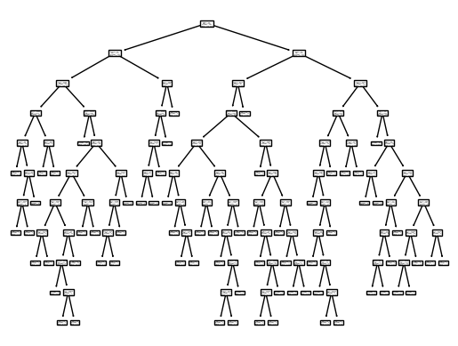

```python
tree.plot_tree(dt)
```

As evident by the decision tree plot, the tree is fairly balanced and deep. Now, we will visualize the learning curve of our classifier, or how classification accuracy progresses as more training examples are used.

```python
from sklearn.model_selection import learning_curve

train_size_abs, train_scores, test_scores = learning_curve(
     dt, test_data_x, test_data_y, train_sizes=[0.2, 0.4, 0.6, 0.8, 1.0]
 )

test_scores_mean = []
train_scores_mean = []

for train_size, cv_train_scores, cv_test_scores in zip(
    train_size_abs, train_scores, test_scores
):
  test_scores_mean.append(cv_test_scores.mean())
  train_scores_mean.append(cv_train_scores.mean())
  #print(f"{train_size} samples were used to train the model")
  #print(f"The average train accuracy is {cv_train_scores.mean():.2f}")
  #print(f"The average test accuracy is {cv_test_scores.mean():.2f}")
```

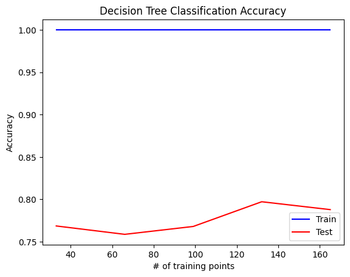

```python
plt.plot([33, 66, 99, 132, 165], train_scores_mean, 'b-',
        ([33, 66, 99, 132, 165]), test_scores_mean, 'r-')
plt.legend( ('Train', 'Test') )
plt.xlabel('# of training points')
plt.ylabel('Accuracy')
plt.title("Decision Tree Classification Accuracy")
```

From the plot, we can tell that training accuracy stays stagnant at 100% as the number of training points increases. On the other hand, testing accuracy hovers around 75-80%, with a rough increase as the number of training points increase. Peak testing accuracy appears to be at 125 training points. Since training accuracy is extremely high and testing accuracy is about 20% away from training accuracy (relatively low) we notice that the model is overfitting the data.

We will see if we can improve the accuracy of our model by introducing a maximum depth parameter to the classifier. Shallower trees are typically less accurate on the training data but generalize better. Based on the decision tree visual above, the tree reached a depth of about 10-11. So, we will go with a max depth of 5– a number that is substantially lower than 10 but hopefully not too little to cause underfitting– and see if it generalizes better.

```python
# initialize the classifier
dt_shallow = tree.DecisionTreeClassifier(max_depth=5)

# train the classifier
dt_shallow.fit(train_data_x, train_data_y)

# predict the Y from the test data
y_pred_dt_shallow = dt_shallow.predict(test_data_x)

# model accuracy
print("Accuracy:", round(metrics.accuracy_score(test_data_y, y_pred_dt_shallow) * 100, 2))

# model f1 score
print("F1 Score:", round(metrics.f1_score(test_data_y, y_pred_dt_shallow)  * 100, 2))
```

```
Accuracy: 83.57
F1 Score: 83.0
```

We can see the accuracy and F1 score have improved over 5%.

```
[Text(0.5138888888888888, 0.9166666666666666, 'x[8] <= 0.5\ngini = 0.491\nsamples = 483\nvalue = [273, 210]'),
```

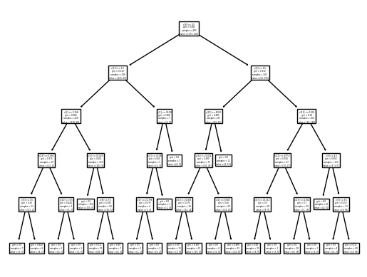

```python
tree.plot_tree(dt_shallow)
```

The tree is much shallower (as expected), and even more balanced than before.

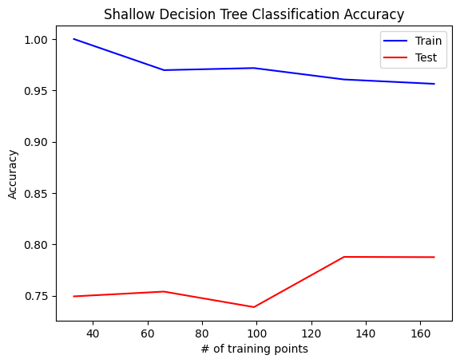

```python
train_size_abs_dts, train_scores_dts, test_scores_dts = learning_curve(
     dt_shallow, test_data_x, test_data_y, train_sizes=[0.2, 0.4, 0.6, 0.8, 1.0]
 )

test_scores_mean_dts = []
train_scores_mean_dts = []

for train_size, cv_train_scores, cv_test_scores in zip(
    train_size_abs_dts, train_scores_dts, test_scores_dts
):
  test_scores_mean_dts.append(cv_test_scores.mean())
  train_scores_mean_dts.append(cv_train_scores.mean())
plt.plot([33, 66, 99, 132, 165], train_scores_mean_dts, 'b-',
        ([33, 66, 99, 132, 165]), test_scores_mean_dts, 'r-')
plt.legend( ('Train', 'Test') )
plt.xlabel('# of training points')
plt.ylabel('Accuracy')
plt.title("Shallow Decision Tree Classification Accuracy")
```

# Random Forest

While a decision tree classifier is easier to interpret, a random forest classifier is often more successful at preventing overfitting. We will see if this holds true for our case by building a random forest classifier using sklearn's [RandomForestClassifier](https://scikit-learn.org/stable/modules/generated/sklearn.ensemble.RandomForestClassifier.html).

```python
from sklearn.ensemble import RandomForestClassifier

# initialize the classifer
rf = RandomForestClassifier(random_state=6)

# train the classifier
rf.fit(train_data_x, train_data_y)

# predict the Y from the test data
y_pred_rf = rf.predict(test_data_x)

# model accuracy
print("Accuracy:", round(metrics.accuracy_score(test_data_y, y_pred_rf) * 100, 2))

# model f1 score
print("F1 Score:", round(metrics.f1_score(test_data_y, y_pred_rf)  * 100, 2))
```

```
Accuracy: 85.51
F1 Score: 84.54
```

We can see we achieve a 1-2% higher accuracy and F1 score than the shallow decision tree classifier.

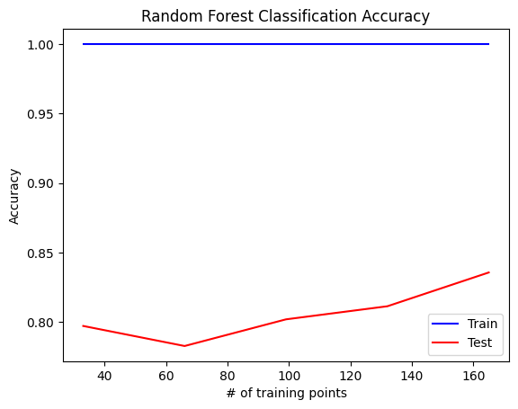

```python
train_size_abs_rf, train_scores_rf, test_scores_rf = learning_curve(
     rf, test_data_x, test_data_y, train_sizes=[0.2, 0.4, 0.6, 0.8, 1.0]
 )

test_scores_mean_rf = []
train_scores_mean_rf = []

for train_size, cv_train_scores, cv_test_scores in zip(
    train_size_abs_rf, train_scores_rf, test_scores_rf
):
  test_scores_mean_rf.append(cv_test_scores.mean())
  train_scores_mean_rf.append(cv_train_scores.mean())
plt.plot([33, 66, 99, 132, 165], train_scores_mean_rf, 'b-',
        ([33, 66, 99, 132, 165]), test_scores_mean_rf, 'r-')
plt.legend( ('Train', 'Test') )
plt.xlabel('# of training points')
plt.ylabel('Accuracy')
plt.title("Random Forest Classification Accuracy")
```

We do still see overfitting present, as the training accuracy remains 100% throughout, but the testing accuracy roughly increases about 5%. This shortens the gap between training accuracy and testing accuracy to about 15%.

# SVM

Support Vector Machines are useful when working with high dimensional data and since our data has a lot of feature values we can say that it exists in a high dimensional space. Thus, we can use SVM with this dataset to try and make predictions. We used [sklearn's LinearSVC](https://scikit-learn.org/stable/modules/generated/sklearn.svm.LinearSVC.html) function instead of the regular SVC with a linear kernel since it has more flexibilty with loss functions and works better with a large number of samples which we have in our dataset.

Since SVM is generally great at binary classification we can expected a high accuracy on the dataset. We will fit the SVM on the same training set as the decision tree so that we can compare the accuracies in a precise manner.

```python
#importing the SVM library from sklearn
from sklearn import svm

#Initializing the LinearSVC
clf = svm.LinearSVC(dual=False)

#Fitting the model with same training data as before
clf.fit(train_data_x, train_data_y)
```

```
LinearSVC(dual=False)
```

After training the SVM we can use it to predict on the test data and then compare the predicted values against the real values to gain the accuracy of the model.

```python
#Predictions based on the same test data as before
y_pred = clf.predict(test_data_x)

#Calculating the accuracy of SVM
print("Accuracy:", round(metrics.accuracy_score(test_data_y, y_pred)*100,2))
```

```
Accuracy: 83.57
```

Our SVM gives an accuracy of 83% which is higher than the decision tree. Let's see if we can do better by fine tuning the regularization hyperparameter.

The regularization hyperparameter C is deafulted to 1.0 but we can test out different values to see if we can achieve a higher accuracy. A smaller C value prefers larger margins & allows more misclassified examples. A larger C value prefers smaller number of misclassified examples, but at the expense of a small margin.

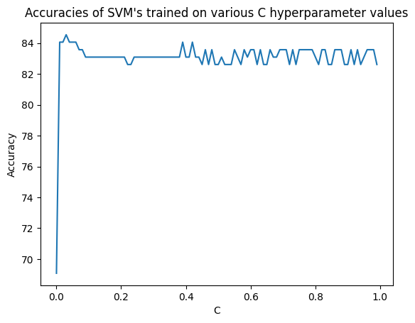

```python
#Different C values to try out
c = np.arange(start=0.0001, stop=1.0, step=0.01)

#Store the accuracies
acc = []

#Store accuracy of SVM on the different C values
for i in c:
  clf = svm.LinearSVC(C=i, dual=False)
  clf.fit(train_data_x, train_data_y)
  y_pred = clf.predict(test_data_x)
  a = round(metrics.accuracy_score(test_data_y, y_pred)*100,2)
  acc.append(a)

#Plotting C values with the corresponding accuracy of SVM
plt.plot(c, acc)
plt.xlabel('C')
plt.ylabel('Accuracy')
plt.title('Accuracies of SVM\'s trained on various C hyperparameter values')
plt.show()
```

```python
#Find the highest accuracy a particular SVM reached
m = np.max(acc)
print("Maximum accuracy achieved:", m)

#Finding the C value corresponding to the largest accuracy
i = acc.index(m)
print("Maximum accuracy achieved at C =", c[i])
```

```
Maximum accuracy achieved: 84.54
Maximum accuracy achieved at C = 0.0301
```

We can also try to see if running a SVM with a polynomail kernel and a radial basis function kernel gives us better results.

```python
#Initializing the LinearSVC
clf_rbf = svm.SVC(kernel='rbf')
clf_poly = svm.SVC(kernel='poly')


#Fitting the model with same training data as before
clf_rbf.fit(train_data_x, train_data_y)
clf_poly.fit(train_data_x, train_data_y)

#Predictions based on the same test data as before
y_pred_rbf = clf_rbf.predict(test_data_x)
y_pred_poly = clf_poly.predict(test_data_x)

#Calculating the accuracy of SVM
print("Accuracy for SVM with RBF kernel:", round(metrics.accuracy_score(test_data_y, y_pred_rbf)*100,2))
print("Accuracy for SVM with Polynomial kernel:", round(metrics.accuracy_score(test_data_y, y_pred_poly)*100,2))
```

```
Accuracy for SVM with RBF kernel: 62.32
Accuracy for SVM with Polynomial kernel: 54.59
```

The SVM with the RBF kernel has 62.32% accuracy and the SVM with polynomial kernel gave an accuracy of about 54.59%. This is worse than the SVM with a linear kernel by about 20%. Thus, the linear SVM does the best.

# K-Nearest Neighbors

The accuracy that we achieve using these other models tells us that they perform fairly well, but let's see if we can do better with KNN. We choose 13 neighbors after testing the model with numerous values and observing the accuracy scores.

```python
from sklearn.neighbors import KNeighborsClassifier

# Initializing the classifier
knn = KNeighborsClassifier(n_neighbors = 13)
```

Next, we will fit the data. We will try to be consistent and use the same train and test data as we used for previous models.

```python
# Fitting model with same train data as decision tree
knn.fit(train_data_x, train_data_y)
```

```
KNeighborsClassifier(n_neighbors=13)
```

Now, let us make the predictions using this data and print the model's final accuracy.

```python
# Predictions based on same test data as decision tree
knn_y_pred = knn.predict(test_data_x)

print("Accuracy:", round(metrics.accuracy_score(test_data_y, knn_y_pred) * 100, 2))

# model f1 score
print("F1 Score:", round(metrics.f1_score(test_data_y, knn_y_pred)  * 100, 2))
```

```
Accuracy: 70.53
F1 Score: 63.47
```

The final accuracy score and the F1 score do not seem to score as high as our previous classification algorithms. Let's visualize this data to see this model performs better with a greater number of training points and if it performs well on the test data.

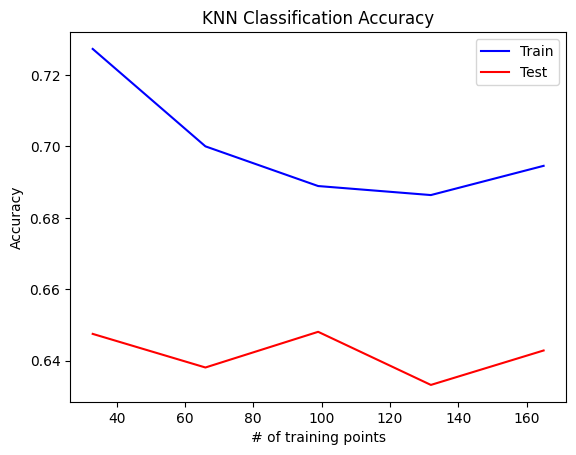

```python
train_size_abs, train_scores, test_scores = learning_curve(
     knn, test_data_x, test_data_y, train_sizes=[0.2, 0.4, 0.6, 0.8, 1.0]
 )

test_scores_mean = []
train_scores_mean = []

for train_size, cv_train_scores, cv_test_scores in zip(
    train_size_abs, train_scores, test_scores):
  test_scores_mean.append(cv_test_scores.mean())
  train_scores_mean.append(cv_train_scores.mean())

plt.plot([33, 66, 99, 132, 165], train_scores_mean, 'b-',
        ([33, 66, 99, 132, 165]), test_scores_mean, 'r-')
plt.legend( ('Train', 'Test') )
plt.xlabel('# of training points')
plt.ylabel('Accuracy')
plt.title("KNN Classification Accuracy")
```

We can see that there are some signs of overfitting as the train accuracy is higher than the test accuracy for all training points. This shows us that the model does not generalize too well to new data points.

Overall, KNN does not perform as well as the previous two models as seen with the accuracy score and F1 score. One explanation for this may be that because KNN does lazy learning and retains all of the information during training, the irrelevant features that don't explain the approval result well may affect the accuracy. In an effort to make these models perform better, let's move on to feature selection and determine which features are actually important!

# Feature Selection

In addition to finding models that predict on the dataset accurately, we also want to figure out which features are important in classifying whether one gets approved for a credit card or not.

We can use [sklearn's Random Forest Classifier](https://scikit-learn.org/stable/modules/generated/sklearn.ensemble.RandomForestClassifier.html) as well as the [SelectFromModel feature selection](https://scikit-learn.org/stable/modules/generated/sklearn.feature_selection.SelectFromModel.html) to understand which features are more important than the others. The random forest classifier trains multiple decision tree classifiers on sub samples of the dataset. It uses gini impurity as the default measure of impurity. We will also train the random forest classifier on the same training dataset as before.

```python
from sklearn.ensemble import RandomForestClassifier
from sklearn.feature_selection import SelectFromModel

#Generate the model
sel = SelectFromModel(RandomForestClassifier())

#Train the model on the training data from before
sel.fit(train_data_x, train_data_y)
```

```
SelectFromModel(estimator=RandomForestClassifier())
```

After training we can select which features are important. The SelectFromModel library selects features whose importance is greater than the mean importance of all the features. The way feature importance is measured for the Random Forest classifier is the decrease in node impurity weighted by the probability of reaching that node. This means that more important features have a higher feature importance value.

```python
#Get the selected features from SelectFromModel
imp = list(sel.get_support())

#List of original features
original = list(train_data_x.columns)

#Collect the names of the features that were selected
features = []
for i in range(len(imp)):
  if imp[i] == True:
    features.append(original[i])

#Printing the features selected
print("Number of total features:", len(train_data_x.columns))
print("Number of selected features:", len(features))
print("Features selected: ")
print(features)
```

```
Number of total features: 14
Number of selected features: 6
Features selected:
['Age', 'Debt', 'YearsEmployed', 'PriorDefault', 'Income', 'PropYearsWorked']
```

We can see from the above the selected features that are important in this dataset to classify whether one gets approved for a credit card or not. Some of these include age, debt, years employed etc.

Some of these features were the ones we looked at while visualizing our data like YearsEmployed and Income. We can see the importance of each feature in relevance to each other as well.

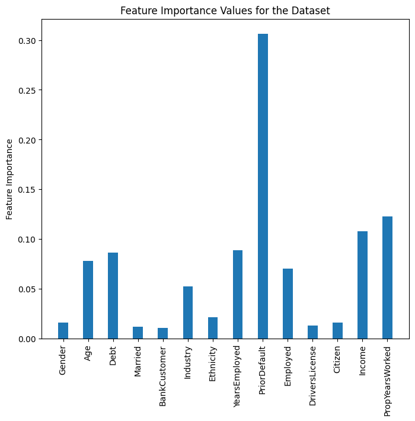

```python
#Get the importance value for each feature
feature_importances = sel.estimator_.feature_importances_.ravel()

#List of the number of features in the dataset
X = np.arange(len(original))

#Setting figure size
fig = plt.figure(figsize =(8, 7))

# Width of a bar
width = 0.4

#Plotting and setting labels
plt.bar(X, feature_importances, width=width)
plt.ylabel('Feature Importance')
plt.title('Feature Importance Values for the Dataset')
plt.xticks(X, original, rotation='vertical')

plt.show()
```

This confirms what we saw above as the features that have a high importance are the ones that were selected. The graphs also shows us that relative to the other features PriorDefault holds the most importance when deciding whether a candidate gets approved for a credit card or not. PriorDefault is whether or not the applicant has ever failed to pay the minimum amount due on the card for several months. This makes sense because bank's don't want to approve people who have failed to pay the minimum amount due on their credit card in the past since this would cause the bank's to lose money.